# IGT Scoring Methods

Annika Kuelpmann

2026-10-07

```r
# read scoring master file
data <- read_xlsx("../../data/raw/metamethod review/master coding/codebook_scoring_master.xlsx")
# read scores overview file
# this is a file with one row per distinct score
monotonic_scores <- read_xlsx("../../data/processed/meta-methods review/scores_overview.xlsx")
# read ID file
# this is a file with original score IDs and new IDs
# used to merge monotonic scores
monotonic_id <- read_xlsx("../../data/raw/metamethod review/master coding/monotonic_scores.xlsx")
```

```r
# Defining functions used in this script

# function 1: overview of a variable
overview_variable <- function(data, variable) {
  data %>%
    select(all_of(variable)) %>%
    group_by(across(all_of(variable))) %>%
    summarise(frequency = n(), .groups = "drop") %>%
    mutate(percentage = round(frequency / sum(frequency) * 100, 2)) %>%
    arrange(desc(frequency))
}

# function 2: summary of frequencies of a variable
freq_summary <- function(data) {
  data %>%
    group_by(frequency) %>%
    summarise(count = n(), .groups = 'drop') %>%
    arrange(desc(frequency))
}
```

```r
# add task_id to data
# and select relevant variables
data <- data %>%
  group_by(article_id, variant) %>%
  mutate(task_id = cur_group_id()) %>%
  ungroup() %>%
  select(article_id, task_id, score_id)

# join info on monotonic scores
# and add variable with respective ID for each score
data <- data %>%
  left_join(monotonic_id, by = "score_id") %>%
  mutate(monotonic_score_id = ifelse(is.na(new_score_id), score_id, new_score_id))

# add frequencies for monotonic scores
data <- data %>%
  group_by(monotonic_score_id) %>%
  mutate(monotonic_score_id_freq = n()) %>%
  ungroup()
```

## Number of Scores

### Total Number of Scores

```r
# count the total number of scores across the whole sample
total_of_scores <- nrow(data)

total_of_scores |>
  kable() |>
  kable_classic(full_width = FALSE)
```

| x |
| --- |
| 806 |

### Number of Scores per Task

We analyzed how many scores were used per task; “number_of_scores” represents the number of scores within a given task, “number_of_tasks” reflects the total number of tasks that had that specific number of scores.

```r
# count the number of scores per task
scores_per_task <- overview_variable(data, "task_id")

# exclude two scores which are derived from two tasks
scores_per_task <- scores_per_task %>%
  filter(task_id != 21)

# summarize the counts of scores per task
scores_per_task_summary <- freq_summary(scores_per_task) %>%
  rename(number_of_scores = frequency, number_of_tasks = count) %>%
  mutate(percent = round(number_of_scores / sum(number_of_scores) * 100, 2))

# print the tibble
scores_per_task_summary |>
  kable() |>
  kable_classic(full_width = FALSE)
```

| number_of_scores | number_of_tasks | percent |
| --- | --- | --- |
| 49 | 1 | 16.96 |
| 30 | 2 | 10.38 |
| 28 | 1 | 9.69 |
| 22 | 3 | 7.61 |
| 20 | 1 | 6.92 |
| 17 | 1 | 5.88 |
| 16 | 1 | 5.54 |
| 15 | 2 | 5.19 |
| 14 | 2 | 4.84 |
| 13 | 3 | 4.50 |
| 12 | 4 | 4.15 |
| 11 | 1 | 3.81 |
| 10 | 4 | 3.46 |
| 8 | 5 | 2.77 |
| 7 | 11 | 2.42 |
| 6 | 25 | 2.08 |
| 5 | 9 | 1.73 |
| 3 | 2 | 1.04 |
| 2 | 6 | 0.69 |
| 1 | 22 | 0.35 |

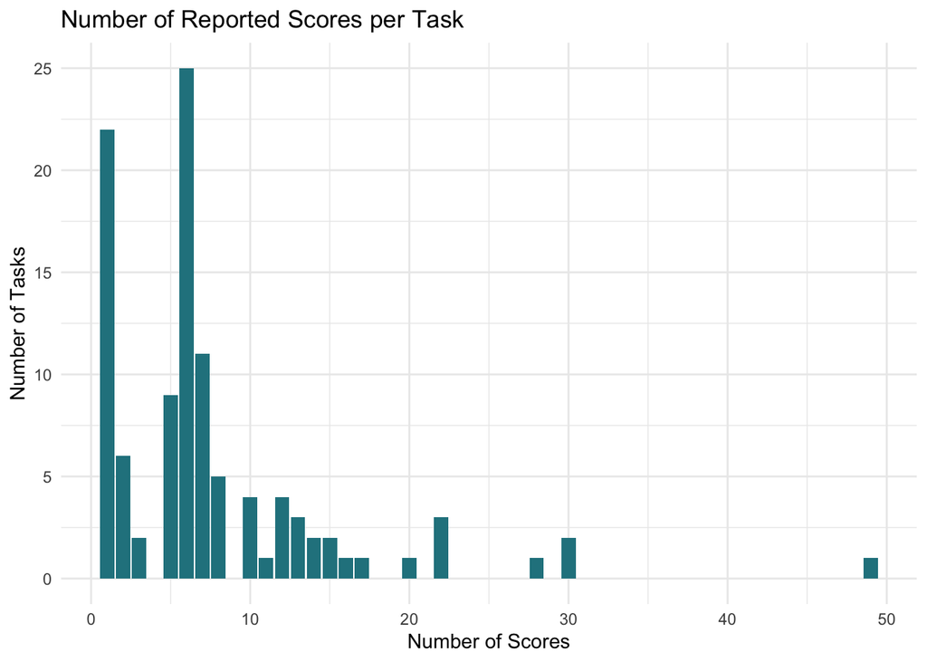

```r
plot1 <- ggplot(scores_per_task_summary,
                aes(x = number_of_scores, y = number_of_tasks)) +
  geom_bar(stat = "identity", fill = "#26828E") +
  labs(
    title = "Number of Reported Scores per Task",
    x = "Number of Scores",
    y = "Number of Tasks"
  ) +
  theme_minimal()

print(plot1)
```

### Summary of Number of Scores per Task

```r
# summary of number of scores per task
summ_per_task <- describe(scores_per_task$frequency)

summ_per_task |>
  kable() |>
  kable_classic(full_width = FALSE)
```

|  | vars | n | mean | sd | median | trimmed | mad | min | max | range | skew | kurtosis | se |
| --- | --- | --- | --- | --- | --- | --- | --- | --- | --- | --- | --- | --- | --- |
| X1 | 1 | 106 | 7.584906 | 7.417955 | 6 | 6.255814 | 5.9304 | 1 | 49 | 48 | 2.516516 | 8.992844 | 0.7204955 |

The total number and the percentage of tasks with a score range of 1 to 8 are as follows:

```r
# proportion of tasks with 1-8 scores
# get the number of tasks with number of scores 8 or less
scores_per_task_minor <- scores_per_task_summary %>%
  filter(number_of_scores <= 8) %>%
  summarise(sum_tasks = sum(number_of_tasks, na.rm = TRUE)) %>%
  pull(sum_tasks)

scores_per_task_minor  |>
  kable() |>
  kable_classic(full_width = FALSE)
```

| x |
| --- |
| 80 |

```r
percent_scores_per_task_minor <- scores_per_task_minor / 107 * 100

percent_scores_per_task_minor |>
  kable() |>
  kable_classic(full_width = FALSE)
```

| x |
| --- |
| 74.76636 |

### Estimate population value of number of scores

```r
# incidence matrix on COLLAPSED scoring methods (monotonic_score_id), i.e.
# after merging score_ids that are linear transformations of one another
# (see `data preparation` chunk above, and the "Number of Distinct Scores"
# section below, which reports the same collapsed count via
# nrow(monotonic_scores))
# rows = articles, columns = collapsed scoring methods
# a method counts as "present" in an article if it occurs in at least one
# task/administration within that article
data_reshaped <- data |>
  select(article_id, monotonic_score_id) |>
  # remove duplicates
  distinct(article_id, monotonic_score_id, .keep_all = TRUE) |>
  mutate(score_used = 1) |>
  pivot_wider(names_from = "monotonic_score_id",
              names_prefix = "scoring_",
              values_from = "score_used",
              values_fill = 0) |>
  column_to_rownames("article_id") |>
  as.matrix()

# sanity check: S_obs must match the collapsed score count reported under
# "Number of Distinct Scores" (nrow(monotonic_scores)). if this fails, the
# monotonic_id collapsing used here and the count reported elsewhere in the
# manuscript have diverged, and the Chao2 estimate below would extrapolate a
# different estimand than the one described in the text -- stop rather than
# silently report a mismatched number
stopifnot(
  "S_obs (collapsed) does not match nrow(monotonic_scores) -- check monotonic_id mapping" =
    ncol(data_reshaped) == nrow(monotonic_scores)
)

# vegan specpool by default computes the classic chao2 estimator with the small sample correction
# it only switches to the bias corrected form when there are no doubletons
chao2_estimate <- vegan::specpool(data_reshaped)

# incidence frequency per scoring method (number of articles it occurs in)
# needed to report Q1 and Q2, since specpool() does not return them
score_incidence <- colSums(data_reshaped > 0)
q1_uniques <- sum(score_incidence == 1)
q2_duplicates <- sum(score_incidence == 2)

# 95% CI following Chao (1987): log-normal and asymmetric around the point
# estimate, appropriate for a non-linear estimator (symmetric +/- 1.96*SE
# is not, since it can extend below S_obs)
# T = estimated number of undetected methods, K = log-normal multiplier
chao2_t <- chao2_estimate$chao - chao2_estimate$Species
chao2_k <- exp(1.96 * sqrt(log(1 + chao2_estimate$chao.se^2 / chao2_t^2)))
chao2_ci_low  <- chao2_estimate$Species + chao2_t / chao2_k
chao2_ci_high <- chao2_estimate$Species + chao2_t * chao2_k

res <- chao2_estimate |>
  as_tibble() |>
  select(scoring_strategies_observed = Species,
         chao2_estimate = chao,
         chao2_se = chao.se) |>
  mutate(q1_uniques = q1_uniques,
         q2_duplicates = q2_duplicates,
         chao2_ci_low = chao2_ci_low,
         chao2_ci_high = chao2_ci_high) |>
  mutate(chao2_estimate = janitor::round_half_up(chao2_estimate, digits = 0),
         chao2_se = janitor::round_half_up(chao2_se, digits = 2),
         chao2_ci_low = janitor::round_half_up(chao2_ci_low, digits = 1),
         chao2_ci_high = janitor::round_half_up(chao2_ci_high, digits = 1))

res |>
  kable() |>
  kable_classic(full_width = FALSE)
```

| scoring_strategies_observed | chao2_estimate | chao2_se | q1_uniques | q2_duplicates | chao2_ci_low | chao2_ci_high |
| --- | --- | --- | --- | --- | --- | --- |
| 244 | 685 | 98.93 | 184 | 38 | 529.7 | 924.9 |

NB Chao$_2$ is a non-linear estimator, so the 95% CI in the table follows Chao (1987) and is log-normal, i.e. asymmetric around the point estimate.

#### Sensitivity analysis: raw (non-collapsed) score IDs

The table below reproduces the Chao$_2$ estimate computed on raw, non-collapsed `score_id`s, kept here for reproducibility of the originally reported estimate (Chao$_2$ = 911, SE = 139.55). This is **not** the estimate used in the main text above: it treats linear-transform variants of the same scoring principle as distinct methods, which is inconsistent with the collapsed count of 244 reported under “Number of Distinct Scores”.

```r
# sensitivity analysis: same procedure as above, but on raw score_id instead
# of the collapsed monotonic_score_id -- object names suffixed `_raw` to
# avoid overwriting the primary results (`res`) used in the text above
data_reshaped_raw <- data |>
  select(article_id, score_id) |>
  distinct(article_id, score_id, .keep_all = TRUE) |>
  mutate(score_used = 1) |>
  pivot_wider(names_from = "score_id",
              names_prefix = "scoring_",
              values_from = "score_used",
              values_fill = 0) |>
  column_to_rownames("article_id") |>
  as.matrix()

chao2_estimate_raw <- vegan::specpool(data_reshaped_raw)

score_incidence_raw <- colSums(data_reshaped_raw > 0)
q1_uniques_raw <- sum(score_incidence_raw == 1)
q2_duplicates_raw <- sum(score_incidence_raw == 2)

chao2_t_raw <- chao2_estimate_raw$chao - chao2_estimate_raw$Species
chao2_k_raw <- exp(1.96 * sqrt(log(1 + chao2_estimate_raw$chao.se^2 / chao2_t_raw^2)))
chao2_ci_low_raw  <- chao2_estimate_raw$Species + chao2_t_raw / chao2_k_raw
chao2_ci_high_raw <- chao2_estimate_raw$Species + chao2_t_raw * chao2_k_raw

res_raw_sensitivity <- chao2_estimate_raw |>
  as_tibble() |>
  select(scoring_strategies_observed = Species,
         chao2_estimate = chao,
         chao2_se = chao.se) |>
  mutate(q1_uniques = q1_uniques_raw,
         q2_duplicates = q2_duplicates_raw,
         chao2_ci_low = chao2_ci_low_raw,
         chao2_ci_high = chao2_ci_high_raw) |>
  mutate(chao2_estimate = janitor::round_half_up(chao2_estimate, digits = 0),
         chao2_se = janitor::round_half_up(chao2_se, digits = 2),
         chao2_ci_low = janitor::round_half_up(chao2_ci_low, digits = 1),
         chao2_ci_high = janitor::round_half_up(chao2_ci_high, digits = 1))

res_raw_sensitivity |>
  kable() |>
  kable_classic(full_width = FALSE)
```

| scoring_strategies_observed | chao2_estimate | chao2_se | q1_uniques | q2_duplicates | chao2_ci_low | chao2_ci_high |
| --- | --- | --- | --- | --- | --- | --- |
| 281 | 911 | 139.55 | 211 | 35 | 690.9 | 1248.2 |

## Distinct Scores

This section aims to present a descriptive overview of the distinct scores identified in the sample.

### Number of Distinct Scores

This reflects the total number of distinct scores identified in our sample following the collapsing of scores that were initially identified as distinct but were also linear transformations of one another. All of the following analyses are done with the collapsed scores.

```r
# count the number of distinct scores in our sample
count_scores <- nrow(monotonic_scores)

count_scores |>
  kable() |>
  kable_classic(full_width = FALSE)
```

| x |
| --- |
| 244 |

### Reusage of Distinct Scores

This illustrates the frequency with which scores were reused within the sample. The variable “times_reused” reflects how often a score occurs in the sample (a value of 1 means the score was never reused), while “number_of_scores” provides the total number of scores that occur with that frequency.

```r
# Count how many scores are reused and how often they are reused
scores_reusage <- overview_variable(data, "monotonic_score_id") %>%
  freq_summary() %>%
  rename(times_reused = frequency, number_of_scores = count) %>%
  mutate(percent = round(number_of_scores / sum(number_of_scores) * 100, 2))

scores_reusage |>
  kable() |>
  kable_classic(full_width = FALSE)
```

| times_reused | number_of_scores | percent |
| --- | --- | --- |
| 88 | 1 | 0.41 |
| 62 | 1 | 0.41 |
| 60 | 4 | 1.64 |
| 18 | 1 | 0.41 |
| 17 | 2 | 0.82 |
| 16 | 1 | 0.41 |
| 13 | 1 | 0.41 |
| 8 | 1 | 0.41 |
| 6 | 2 | 0.82 |
| 5 | 7 | 2.87 |
| 3 | 11 | 4.51 |
| 2 | 35 | 14.34 |
| 1 | 177 | 72.54 |

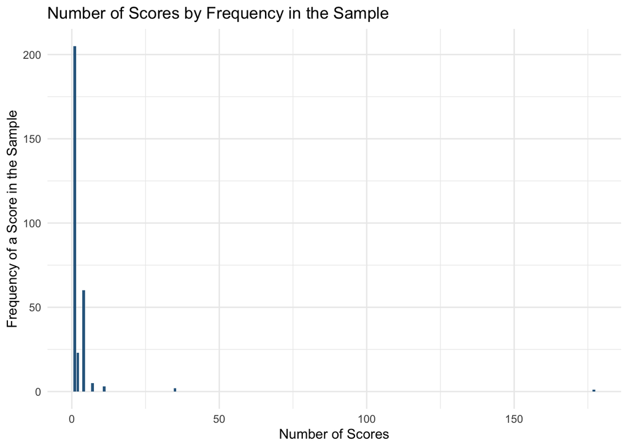

```r
plot2 <- ggplot(scores_reusage,
                aes(x = number_of_scores, y = times_reused)) +
  geom_col(fill = "#31688E") +
  theme_minimal() +
  labs(
    title = "Number of Scores by Frequency in the Sample",
    x = "Number of Scores",
    y = "Frequency of a Score in the Sample"
    )

print(plot2)
```

In order to simplify the overview, we have categorized the reuse of scores according to the following criteria: A unique score occurs only once in the sample and has thus never been reused. A rare score occurs two to nine times in the sample. Finally, a common score occurs ten or more times in the sample.

```r
# Add score_freq_category variable to data
data <- data %>%
  mutate(score_freq_category = case_when(
    monotonic_score_id_freq == 1 ~ "unique",
    monotonic_score_id_freq < 10 ~ "rare",
    monotonic_score_id_freq >= 10 ~ "common"
  ))

scores_frequencies <- overview_variable(data, "score_freq_category")

scores_frequencies |>
  kable() |>
  kable_classic(full_width = FALSE)
```

| score_freq_category | frequency | percentage |
| --- | --- | --- |
| common | 471 | 58.44 |
| unique | 177 | 21.96 |
| rare | 158 | 19.60 |

### Types of Scores

The following section presents a quantification of the scores, categorized according to the types identified in the sample. “frequency” reflects the number of distinct scores that have been categorized within that particular group.

```r
# proportion of distinct scores per type
score_types <- overview_variable(monotonic_scores, "category")

score_types |>
  kable() |>
  kable_classic(full_width = FALSE)
```

| category | frequency | percentage |
| --- | --- | --- |
| single deck score | 92 | 37.70 |
| net score | 61 | 25.00 |
| categorized score | 23 | 9.43 |
| choice behavior | 17 | 6.97 |
| model parameter | 16 | 6.56 |
| indeterminable | 12 | 4.92 |
| money | 6 | 2.46 |
| loss frequency based score | 5 | 2.05 |
| other | 4 | 1.64 |
| autocorrelation | 3 | 1.23 |
| difference score | 3 | 1.23 |
| score across two variants | 2 | 0.82 |

A closer look at the tasks that used model parameters:

```r
# select model parameter scores used across tasks
model_parameters <- data %>%
  select(task_id, monotonic_score_id) %>%
  left_join(monotonic_scores, by = "monotonic_score_id") %>%
  filter(category == "model parameter")

# view the tasks that used igt models as scoring approaches
igt_models <- model_parameters %>%
   select(task_id, scoring_approach) %>%
   distinct(task_id, .keep_all = TRUE)

igt_models |>
  kable() |>
  kable_classic(full_width = FALSE)
```

| task_id | scoring_approach |
| --- | --- |
| 12 | VPP model |
| 103 | TDRL model |
| 13 | EV model |
| 27 | EV model |
| 32 | EV model |
| 42 | EV model |
| 45 | EV model |

## Common Scores

This is an analysis of the most frequently used scores in our sample. The 10 most prevalent scores were the net score across all trials (1001), the net scores across five blocks of 20 trials (1002, 1003, 1004, 1005, 1006), and the deck selections across all trials for each of the four decks A to D (1011, 1020, 1029, 1038). These scores were reused more than ten times across the whole sample and thus are matching the “common” category introduced above.

```r
# find the most frequently used scores
# count the occurrences of each monotonic_score_id
score_counts <- overview_variable(data, "monotonic_score_id")

# identify the 10 most common scores
top_10_scores <- score_counts %>%
  top_n(10, wt = frequency)

top_10_scores |>
  kable() |>
  kable_classic(full_width = FALSE)
```

| monotonic_score_id | frequency | percentage |
| --- | --- | --- |
| 1001 | 88 | 10.92 |
| 1006 | 62 | 7.69 |
| 1002 | 60 | 7.44 |
| 1003 | 60 | 7.44 |
| 1004 | 60 | 7.44 |
| 1005 | 60 | 7.44 |
| 1011 | 18 | 2.23 |
| 1020 | 17 | 2.11 |
| 1038 | 17 | 2.11 |
| 1029 | 16 | 1.99 |

The proportion of these 10 common scores within our sample is as follows:

```r
### find out how large the proportion of the most frequent scores is
# filter the data frame to keep only the rows with the top 10 scores
top_10_scores <- top_10_scores %>%
  pull(monotonic_score_id)

filtered_data_top_10 <- data %>%
  filter(monotonic_score_id %in% top_10_scores)

# Count the occurrences of these top 10 scores
top_10_score_counts <- filtered_data_top_10 %>%
  summarise(count = n())

# Calculate the proportion of the top 10 scores
proportion_top_10 <- (top_10_score_counts$count / total_of_scores) * 100

proportion_top_10 |>
  kable() |>
  kable_classic(full_width = FALSE)
```

| x |
| --- |
| 56.82382 |

This is the number of tasks that would use at least one of the 10 most common scores, as well as the number of tasks that would use only these 10 scores:

```r
# find out how many tasks use at least one of them
# Count the number of unique task_ids associated with these top 10 scores
tasks_with_top_10 <- filtered_data_top_10 %>%
  select(task_id) %>%
  distinct()

number_tasks_with_top_10 <- nrow(tasks_with_top_10)

number_tasks_with_top_10 |>
  kable() |>
  kable_classic(full_width = FALSE)
```

| x |
| --- |
| 92 |

```r
# Count the number of unique task_ids associated with only top 10 scores (reporting no other scores)
tasks_with_only_top_10 <- data %>%
  group_by(task_id) %>%
  filter(all(monotonic_score_id %in% top_10_scores)) %>%
  distinct(task_id)

number_tasks_with_only_top_10 <- nrow(tasks_with_only_top_10)

number_tasks_with_only_top_10 |>
  kable() |>
  kable_classic(full_width = FALSE)
```

| x |
| --- |
| 45 |

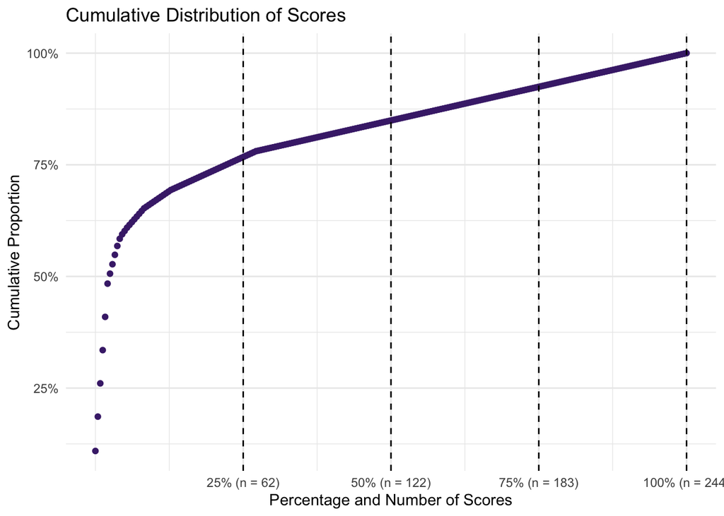

```r
# cumulative proportion
scores_cumulative <- data %>%
  count(monotonic_score_id) %>%
  arrange(desc(n)) %>%
  mutate(
    cumulative_count = cumsum(n),
    cumulative_proportion = cumulative_count / sum(n)
  )

# calculate positions for quantiles
quantile_positions <- quantile(seq_len(nrow(scores_cumulative)), c(0.25, 0.50, 0.75, 1.00))

# round positions to get the number of scores at each quantile
quantile_counts <- round(quantile_positions)

# define labels
quantile_labels <- paste0(
  c("25%", "50%", "75%", "100%"),
  " (n = ", quantile_counts, ")"
)

# plot
plot3 <- ggplot(scores_cumulative,
                aes(x = seq_len(nrow(scores_cumulative)), y = cumulative_proportion)) +
  geom_point(color = "#482878") +
  geom_vline(xintercept = quantile_positions, linetype = "dashed", color = "black") +
  labs(
    x = "Percentage and Number of Scores",
    y = "Cumulative Proportion",
    title = "Cumulative Distribution of Scores"
  ) +
  theme_minimal() +
  scale_y_continuous(labels = scales::percent) +  # Convert y-axis labels to percentages
  scale_x_continuous(
    breaks = quantile_positions,
    labels = quantile_labels
  )

print(plot3)
```

### Tasks Using the Net Score

Here we present the number of tasks that employ the net score across all trials, irrespective of the number of other scores provided. Additionally, we present the number of tasks that solely provide the net score without including other scores.

```r
# Filter tasks containing net score across all trials (score_id 1001)
tasks_with_net_score <- data %>%
  select(task_id, monotonic_score_id) %>%
  filter(monotonic_score_id == 1001)

# Count the number of tasks containing net score across all trials
num_tasks_with_net_score <- tasks_with_net_score %>%
  distinct(task_id) %>%
  nrow()

num_tasks_with_net_score |>
  kable() |>
  kable_classic(full_width = FALSE)
```

| x |
| --- |
| 75 |

```r
# Identify tasks with net score reported only
tasks_with_net_score_only <- data %>%
  group_by(task_id) %>%
  filter(all(monotonic_score_id == 1001)) %>%
  ungroup()

# Count the number of tasks with net score reported only
num_tasks_with_net_score_only <- tasks_with_net_score_only %>%
  distinct(task_id) %>%
  nrow()

num_tasks_with_net_score_only |>
  kable() |>
  kable_classic(full_width = FALSE)
```

| x |
| --- |
| 18 |

### Tasks Using the Learning Index

Here we present the number of tasks that employed net scores across five blocks of 20 trials in conjunction with one another, thereby providing the conventional learning index. Secondly, the number of tasks providing only this learning index without utilising other scores is presented.

```r
# Filter tasks containing learning index across 5 blocks of 20 trials (score_id 1002 to 1006)
# Define the vector of monotonic_score_id values
required_scores <- c(1002, 1003, 1004, 1005, 1006)

tasks_with_learning_index <- data %>%
  filter(monotonic_score_id %in% required_scores) %>%
  group_by(task_id) %>%
  summarise(count_learning_index = n_distinct(monotonic_score_id)) %>%
  filter(count_learning_index == length(required_scores)) %>%
  select(task_id)

# count the number of tasks reporting the full learning index
num_tasks_with_learning_index <- nrow(tasks_with_learning_index)

num_tasks_with_learning_index |>
  kable() |>
  kable_classic(full_width = FALSE)
```

| x |
| --- |
| 56 |

```r
# Identify tasks with learning index reported only
tasks_with_learning_index_only <- data %>%
  group_by(task_id) %>%
  filter(all(monotonic_score_id %in% required_scores)) %>%
  ungroup()

# Count the number of tasks with learning index reported only
num_tasks_with_learning_index_only <- tasks_with_learning_index_only %>%
  distinct(task_id) %>%
  nrow()

num_tasks_with_learning_index_only |>
  kable() |>
  kable_classic(full_width = FALSE)
```

| x |
| --- |
| 6 |

Here we present the number of tasks that employ both the net score across all trials, and the learning index, irrespective of other scores. Secondly, we present the number of tasks that provide only the net score and learning index.

```r
# Find tasks that contain both net score and learning index
# Define the vector of monotonic_score_id values for that case
required_scores_both <- c(1001, 1002, 1003, 1004, 1005, 1006)

tasks_with_both <- data %>%
  filter(monotonic_score_id %in% required_scores_both) %>%
  group_by(task_id) %>%
  summarise(count_both = n_distinct(monotonic_score_id)) %>%
  filter(count_both == length(required_scores_both)) %>%
  select(task_id)

num_tasks_with_both <- nrow(tasks_with_both)

num_tasks_with_both  |>
  kable() |>
  kable_classic(full_width = FALSE)
```

| x |
| --- |
| 41 |

```r
# Identify tasks with net score and learning index reported only
tasks_with_both_only <- data %>%
  group_by(task_id) %>%
  filter(all(monotonic_score_id %in% required_scores_both) &
         all(required_scores_both %in% monotonic_score_id)) %>%
  ungroup()

# Count the number of tasks with net score and learning index reported only
num_tasks_with_both_only <- tasks_with_both_only %>%
  distinct(task_id) %>%
  nrow()

num_tasks_with_both_only  |>
  kable() |>
  kable_classic(full_width = FALSE)
```

| x |
| --- |
| 18 |

Here we present the number of tasks that used either the learning index or the net score across all trials, or both.

```r
# Find tasks that contain either net score or learning index
tasks_with_either <- tasks_with_net_score %>%
  full_join(tasks_with_learning_index, by = "task_id") %>%
  distinct(task_id)

# Count the number of tasks containing either net score or learning index
num_tasks_with_either <- nrow(tasks_with_either)

num_tasks_with_either  |>
  kable() |>
  kable_classic(full_width = FALSE)
```

| x |
| --- |
| 90 |

### Tasks Using Single Deck Selections

Here we present the number of tasks that employed the single deck selections for decks A, B, C, and D across all trials in conjunction with one another. Secondly, the number of tasks providing only these four scores without utilizing other scores is presented.

```r
# Filter tasks containing the deck selections for each of the four decks across all trials
# Define the vector of monotonic_score_id values
required_scores_ABCD <- c(1011, 1020, 1029, 1038)

tasks_with_ABCD <- data %>%
  filter(monotonic_score_id %in% required_scores_ABCD) %>%
  group_by(task_id) %>%
  summarise(count_abcd = n_distinct(monotonic_score_id)) %>%
  filter(count_abcd == length(required_scores_ABCD)) %>%
  select(task_id)

# count the number of tasks reporting all four single deck selections
num_tasks_with_ABCD <- nrow(tasks_with_ABCD)

num_tasks_with_ABCD  |>
  kable() |>
  kable_classic(full_width = FALSE)
```

| x |
| --- |
| 16 |

```r
# identify tasks reporting only the four single deck selections
tasks_with_ABCD_only <- data %>%
  group_by(task_id) %>%
  filter(all(monotonic_score_id %in% required_scores_ABCD)) %>%
  ungroup()

# count the number of tasks reporting only the four single deck selections
num_tasks_with_ABCD_only <- tasks_with_ABCD_only %>%
  distinct(task_id) %>%
  nrow()

num_tasks_with_ABCD_only  |>
  kable() |>
  kable_classic(full_width = FALSE)
```

| x |
| --- |
| 0 |

## Unique Scores

Here we provide a descriptive analysis of the number of unique scores, defined as those that were present only once in the sample.

```r
# count how many scores are unique in the sample
number_of_unique_scores <- scores_reusage %>%
  filter(times_reused == 1)

number_of_unique_scores  |>
  kable() |>
  kable_classic(full_width = FALSE)
```

| times_reused | number_of_scores | percent |
| --- | --- | --- |
| 1 | 177 | 72.54 |

This is the proportion of unique scores within our sample:

```r
### find out how large the proportion of the unique scores is
# filter the data frame to keep only the rows with unique scores
unique_scores <- score_counts %>%
  filter(frequency == 1) %>%
  pull(monotonic_score_id)

filtered_data_unique_scores <- data %>%
  filter(monotonic_score_id %in% unique_scores)

# Count the occurrences of unique scores
unique_score_counts <- filtered_data_unique_scores %>%
  summarise(count = n())

# Calculate the proportion of the unique scores
proportion_unique_scores <- (unique_score_counts$count / total_of_scores) * 100

proportion_unique_scores |>
  kable() |>
  kable_classic(full_width = FALSE)
```

| x |
| --- |
| 21.9603 |

The following table presents the number of unique scores per task: “unique_scores” indicates the number of scores that are exclusive to a given task, while “frequency” reflects the number of tasks in which that number of unique scores has been obtained.

```r
# flag unique scores per task
unique_counts <- data %>%
  left_join(score_counts, by = "monotonic_score_id") %>%
  select(task_id, monotonic_score_id, frequency) %>%
  group_by(task_id, monotonic_score_id) %>%
  summarise(unique_scores = any(frequency == "1"), .groups = 'drop')

# count unique scores per task
unique_counts <- unique_counts %>%
  group_by(task_id) %>%
  summarise(
    uniques = sum(unique_scores == TRUE)
  )

# summarize the frequencies of unique scores within tasks
uniques_per_task <- overview_variable(unique_counts, "uniques") %>%
  rename(unique_scores = uniques)

uniques_per_task |>
  kable() |>
  kable_classic(full_width = FALSE)
```

| unique_scores | frequency | percentage |
| --- | --- | --- |
| 0 | 71 | 66.36 |
| 1 | 16 | 14.95 |
| 2 | 5 | 4.67 |
| 6 | 5 | 4.67 |
| 4 | 2 | 1.87 |
| 3 | 1 | 0.93 |
| 5 | 1 | 0.93 |
| 8 | 1 | 0.93 |
| 9 | 1 | 0.93 |
| 10 | 1 | 0.93 |
| 16 | 1 | 0.93 |
| 22 | 1 | 0.93 |
| 40 | 1 | 0.93 |

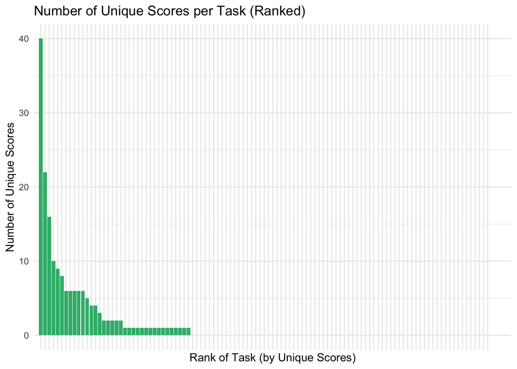

```r
unique_counts <- unique_counts %>%
  arrange(desc(uniques)) %>%
  mutate(rank = row_number())

plot4 <- ggplot(unique_counts, aes(x = factor(rank), y = uniques)) +
  geom_bar(stat = "identity", fill = "#35B779") +
  theme_minimal() +
  labs(
    title = "Number of Unique Scores per Task (Ranked)",
    x = "Rank of Task (by Unique Scores)",
    y = "Number of Unique Scores"
  ) +
  theme(
    axis.text.x = element_blank()) +
  coord_cartesian(xlim = c(0, nrow(unique_counts) + 5))

print(plot4)
```

The following table demonstrates the degree of overlap between tasks that have been assigned unique, rare, or common scores.

| has_common | has_rare | has_unique | count |
| --- | --- | --- | --- |
| FALSE | FALSE | TRUE | 7 |
| FALSE | TRUE | FALSE | 2 |
| FALSE | TRUE | TRUE | 4 |
| TRUE | FALSE | FALSE | 50 |
| TRUE | FALSE | TRUE | 16 |
| TRUE | TRUE | FALSE | 19 |
| TRUE | TRUE | TRUE | 9 |

## Indeterminable Scores

An indeterminable score is a score with elements that are not clearly defined or that has not been adequately described. We have classified indeterminable scores as unique, given that it was not possible to determine whether an indeterminable score was distinct or not. The total number of indeterminable scores identified in our sample is as follows:

```r
indeterminable_scores <- monotonic_scores %>%
  filter(if_any(everything(), ~ .x == "indeterminable")) %>%
  # Remove three rows with scores that had indeterminable elements initially,
  # but were identified in a second step and implemented in the multiverse,
  # so they are no longer counted as indeterminable scores
  filter(!monotonic_score_id %in% c(4016, 3005, 3025))


number_of_indeterminable_scores <- nrow(indeterminable_scores)

number_of_indeterminable_scores |>
  kable() |>
  kable_classic(full_width = FALSE)
```

| x |
| --- |
| 21 |

Here we present the number of indeterminable scores per task. “indeterminable_scores” represents the number of scores identified as indeterminable within a given task, “frequency” reflects the number of tasks with that specific number of indeterminable scores.

```r
# flag indeterminable scores per task
indeterminable_counts <- data %>%
  left_join(monotonic_scores, by = "monotonic_score_id") %>%
  select(article_id, task_id, monotonic_score_id, category) %>%
  group_by(article_id, task_id, monotonic_score_id) %>%
  summarise(indeterminable = any(category == "indeterminable"),
            .groups = 'drop')

# count indeterminable scores per task
indeterminable_counts <- indeterminable_counts %>%
  group_by(article_id, task_id) %>%
  summarise(
    indeterminable_scores = sum(indeterminable == TRUE),
    .groups = 'drop'
  )

# summarize number of indeterminable scores
indeterminable_counts_summary <- overview_variable(indeterminable_counts, "indeterminable_scores")

indeterminable_counts_summary |>
  kable() |>
  kable_classic(full_width = FALSE)
```

| indeterminable_scores | frequency | percentage |
| --- | --- | --- |
| 0 | 100 | 93.46 |
| 1 | 5 | 4.67 |
| 2 | 1 | 0.93 |
| 6 | 1 | 0.93 |